# Open NEON H5 File

Leah A. Wasser

April 28, 2016

First, let’s load the required libraries.

[output not shown]

## Explore File

Next, define the file name and view the contents quickly.

```r
# define the file name as an object
f <- "Subset1NIS1_20130614_095740_atmcor.h5"

# view the structure of the file
# reflectance is where the refl data are stored.
# map info contains the proj information in WKT format
h5ls(f)
```

```
##    group                                 name       otype  dclass
## 0      /                     ATCOR_Input_File H5I_DATASET  STRING
## 1      /                 ATCOR_Processing_Log H5I_DATASET  STRING
## 2      /                Aerosol Optical Depth H5I_DATASET INTEGER
## 3      /                               Aspect H5I_DATASET   FLOAT
## 4      /                          Cast Shadow H5I_DATASET INTEGER
## 5      / Dark Dense Vegetation Classification H5I_DATASET INTEGER
## 6      /                 Haze-Cloud-Water Map H5I_DATASET INTEGER
## 7      /                  Illumination Factor H5I_DATASET INTEGER
## 8      /                          Path Length H5I_DATASET   FLOAT
## 9      /                   Processing Version H5I_DATASET  STRING
## 10     /                          Reflectance H5I_DATASET INTEGER
## 11     /                Shadow_Processing_Log H5I_DATASET  STRING
## 12     /                      Sky View Factor H5I_DATASET INTEGER
## 13     /               Skyview_Processing_Log H5I_DATASET  STRING
```

[output cut: 47 more lines]

```r
# let's grab some attribute information to use
# here we have the CRS information that includes the
# UPPER LEFT corner coordinate in UTM (meters)
mapInfo <- h5read(f,"map info")
mapInfo
```

```
## [1] "UTM,1,1,326403.0,4103390.0,1.0000000000e+000,1.0000000000e+000,11,North,WGS-84,units=Meters"
```

## View Wavelengths

Next, let’s import some wavelength information.

```r
# import the center wavelength in um of each "band"
wavelengths<- h5read(f,"wavelength")
```

# notice the data ignore is a character.

```r
# r  get attributes for the Reflectance dataset
reflInfo <- h5readAttributes(f,"Reflectance")

# view the scale factor for the data
reflInfo$`Scale Factor`
```

```
## [1] 10000
```

```r
# view the data ignore value
reflInfo$`data ignore value`
```

```
## [1] "15000.0"
```

```r
# the data ignore right now is a character (we are fixing this)
# you have to conver to num or int to ensure it is useful!
```

# Get shape of reflectance dataset

Let’s read the data to grab the dimensions. note: in a future version of the data we will have the dimensions as ATTRIBUTES that you can automatically pull in

```r
# open the file for viewing
fid <- H5Fopen(f)
# open the reflectance dataset
did <- H5Dopen(fid, "Reflectance")
did
```

```
## HDF5 DATASET
##
##         name /Reflectance
##     filename
##         type H5T_STD_I16LE
##         rank 3
##         size 684 x 787 x 426
##      maxsize 684 x 787 x 426
```

```r
# grab the dimensions of the object
sid <- H5Dget_space(did)
dims <- H5Sget_simple_extent_dims(sid)$size

# take note that the data seem to come in ROTATED. wavelength is the
# THIRD dimension rather than the first. Columns are the FIRST dimension, then rows.
# close everything
H5Sclose(sid)
H5Dclose(did)
H5Fclose(fid)
```

```r
# if you get an error with the file being "open" just use the generic h5 close below
# when we are done with our attributes you can skip all of this nonsense :)
H5close()
# Extract or "slice" data for band 34 from the HDF5 file
b56<- h5read(f,"Reflectance", index=list(1:dims[1],1:dims[2],56))
# note the data come in as an array
class(b56)
```

```
## [1] "array"
```

Next, we will convert the data to a matrix and then to a raster. We don’t need an array because our data are only 2 dimensions at this point (1 single band).

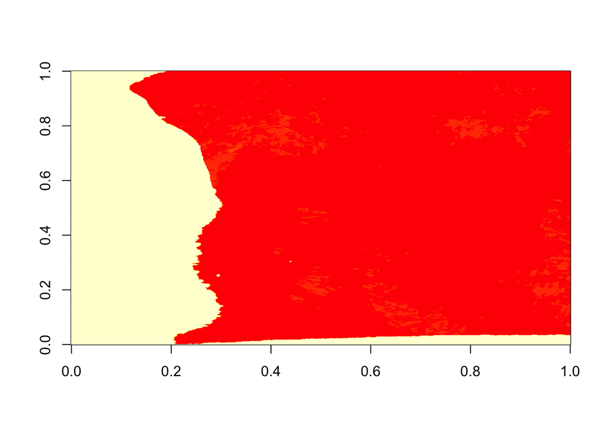

```r
# Convert from array to matrix so we can plot and convert to a raster
b56 <- b56[,,1]

# plot the data
# what happens when we plot?
image(b56)
```

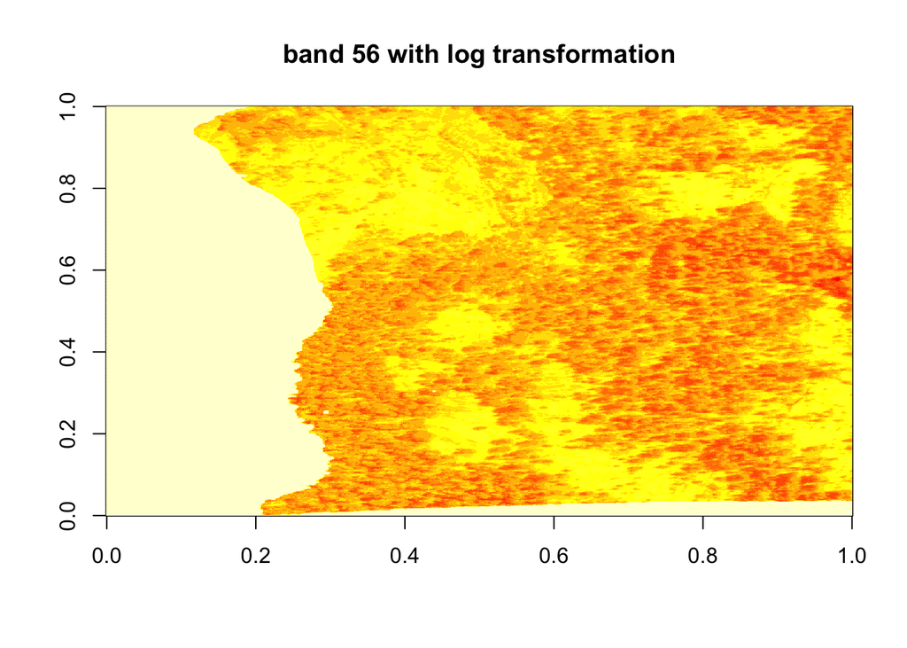

```r
# looks like we need to force a stretch
image(log(b56), main="band 56 with log transformation")
```

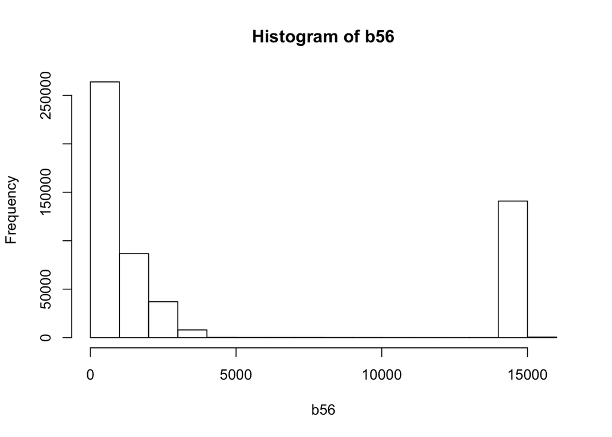

```r
# view distribution
hist(b56)
```

Ok so now we need to do a few things

1. set the no data value (15000)
2. scale the data by 10000

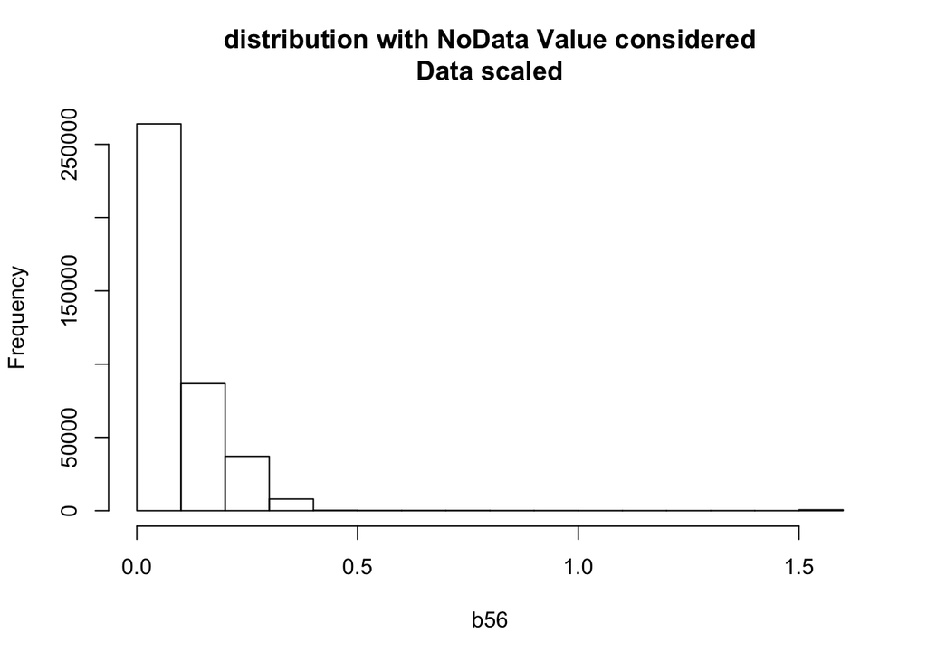

```r
noDataVal <- as.integer(reflInfo$`data ignore value`)
# set all values = 15,000 to NA
b56[b56 == noDataVal] <- NA

# lets use our scale factor first
scaleFactor <- reflInfo$`Scale Factor`
b56 <- b56/scaleFactor

hist(b56, main="distribution with NoData Value considered\nData scaled")
```

Note – there are still issues with values over 1. I need to followup with AOP about how to handle these.

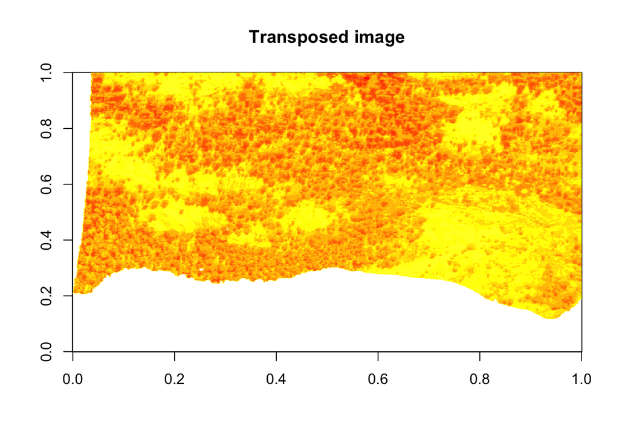

```r
# Because the data import column, row but we require row, column in R,
# We need to transpose x and y values in order for our final image to plot properly
b56<-t(b56)
image(log(b56), main="Transposed image")
```

Next, we need to create the spatial extent required to position the raster in space.

```r
# so we can extract the lower left hand corner coordinates.
# the numbers as position 4 and 5 are the UPPER LEFT CORNER (x,y)
mapInfo<-unlist(strsplit(mapInfo, ","))

# grab the XY left corner coordinate
xMin <- as.numeric(mapInfo[4])
# ensure the format is numeric
yMax <- as.numeric(mapInfo[5])
# we can get the x and y resolution from this string too
res <- c(mapInfo[2],mapInfo[3])
res <- as.numeric(res)

#  finally calculate the xMAX value and the YMIN value
# we grabbed the dimensions above. the xmax is the left corner + number of columns* resolution
xMax <- xMin + (dims[1]*res[1])
yMin <- yMax - (dims[2]*res[2])

# also note that x and y res are the same (1 meter)
# Now, define the raster extent
# define the extent (left, right, top, bottom)
rasExt <- extent(xMin, xMax,yMin,yMax)

# now we can create a raster and assign it it's spatial extent
b56r <- raster(b56,
               crs=CRS("+init=epsg:32611"))
# assign CRS
extent(b56r) <- rasExt

# note that the raster flips the data once again.
# i still need to sort out how to explain this but it has to do with how
# the raster format nativly is stored.
b56r
```

```
## class       : RasterLayer
## dimensions  : 787, 684, 538308  (nrow, ncol, ncell)
## resolution  : 1, 1  (x, y)
## extent      : 326403, 327087, 4102603, 4103390  (xmin, xmax, ymin, ymax)
## coord. ref. : +init=epsg:32611 +proj=utm +zone=11 +datum=WGS84 +units=m +no_defs +ellps=WGS84 +towgs84=0,0,0
## data source : in memory
## names       : layer
## values      : 9e-04, 1.5551  (min, max)
```

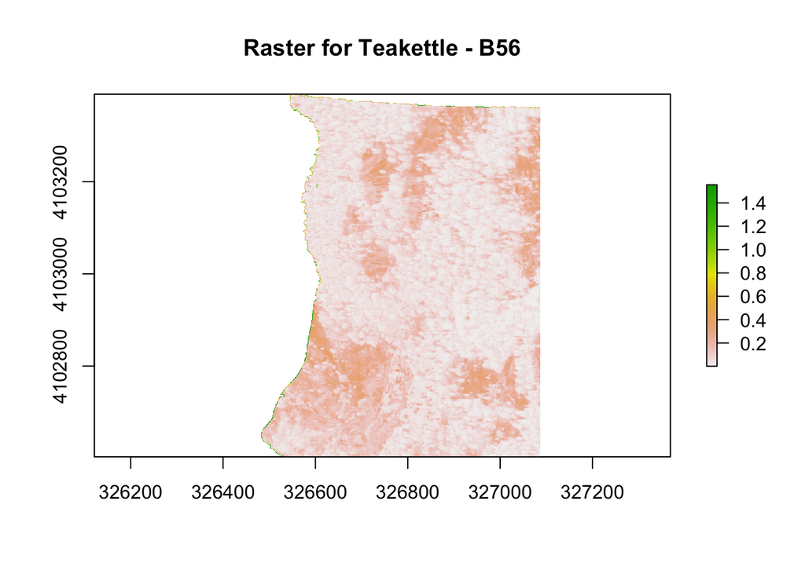

```r
plot(b56r, main="Raster for Teakettle - B56")
```